# Data Analyst Nanodegree IV-Explore and Summarize Data by Manas Sarma

January 11, 2017

# Introduction

For this project, I analyzed loan data obtained from Prosper which was obtained from the 2009 housing crisis. I chose this data set because after seeing The Big Short last winter, I became inspired to find out about the different types of loans.

```
## [1] "The number of rows is 113937"
```

```
## [1] "The number of columns is 81"
```

# Univariate Plots section

```
## 'data.frame':    113937 obs. of  81 variables:
##  $ ListingKey                         : Factor w/ 113066 levels "00003546482094282EF90E5",..: 7180 7193 6647 6669 6686 6689 6699 6706 6687 6687 ...
##  $ ListingNumber                      : int  193129 1209647 81716 658116 909464 1074836 750899 768193 1023355 1023355 ...
##  $ ListingCreationDate                : Factor w/ 113064 levels "2005-11-09 20:44:28.847000000",..: 14184 111894 6429 64760 85967 100310 72556 74019 97834 97834 ...
##  $ CreditGrade                        : Factor w/ 9 levels "","A","AA","B",..: 5 1 8 1 1 1 1 1 1 1 ...
##  $ Term                               : int  36 36 36 36 36 60 36 36 36 36 ...
##  $ LoanStatus                         : Factor w/ 12 levels "Cancelled","Chargedoff",..: 3 4 3 4 4 4 4 4 4 4 ...
##  $ ClosedDate                         : Factor w/ 2803 levels "","2005-11-25 00:00:00",..: 1138 1 1263 1 1 1 1 1 1 1 ...
##  $ BorrowerAPR                        : num  0.165 0.12 0.283 0.125 0.246 ...
##  $ BorrowerRate                       : num  0.158 0.092 0.275 0.0974 0.2085 ...
##  $ LenderYield                        : num  0.138 0.082 0.24 0.0874 0.1985 ...
##  $ EstimatedEffectiveYield            : num  NA 0.0796 NA 0.0849 0.1832 ...
##  $ EstimatedLoss                      : num  NA 0.0249 NA 0.0249 0.0925 ...
##  $ EstimatedReturn                    : num  NA 0.0547 NA 0.06 0.0907 ...
##  $ ProsperRating..numeric.            : int  NA 6 NA 6 3 5 2 4 7 7 ...
```

[output cut: 67 more lines]

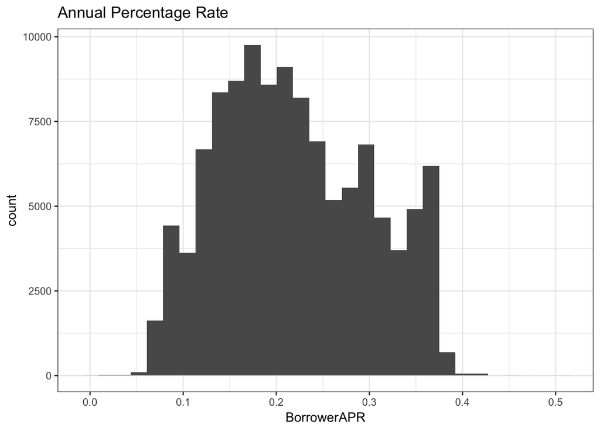

```
##    Min. 1st Qu.  Median    Mean 3rd Qu.    Max.    NA's
## 0.00653 0.15630 0.20980 0.21880 0.28380 0.51230      25
```

This is a histogram of the BorrowerAPR. The BorrowerAPR is the borrower’s annual percentage rate for the loan. The APR is the interest rate on the loan for the whole year.

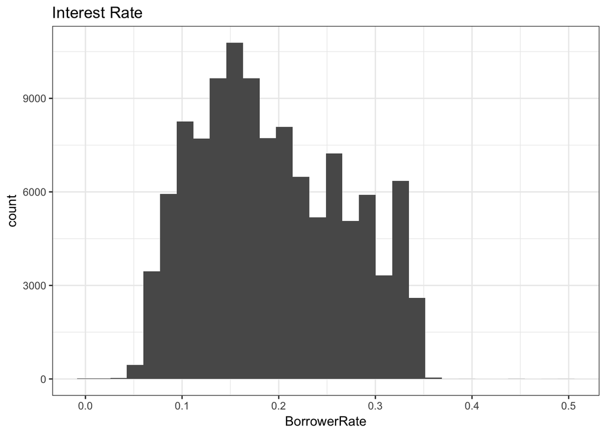

```
##    Min. 1st Qu.  Median    Mean 3rd Qu.    Max.
##  0.0000  0.1340  0.1840  0.1928  0.2500  0.4975
```

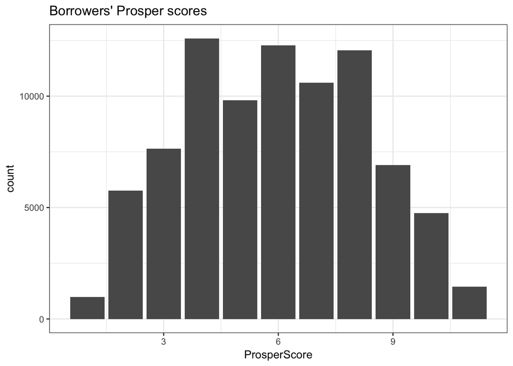

```
##    Min. 1st Qu.  Median    Mean 3rd Qu.    Max.    NA's
##    1.00    4.00    6.00    5.95    8.00   11.00   29084
```

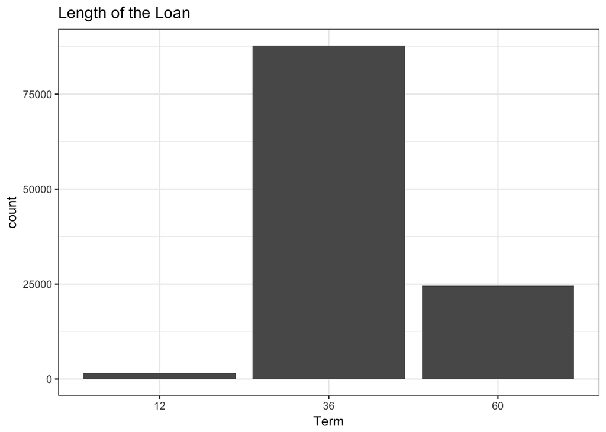

```
##    12    36    60
##  1614 87778 24545
```

This is a histogram of the term, or length, of each loan. The units here are in months, so all the loans are valid for 1, 3, or 5 years.

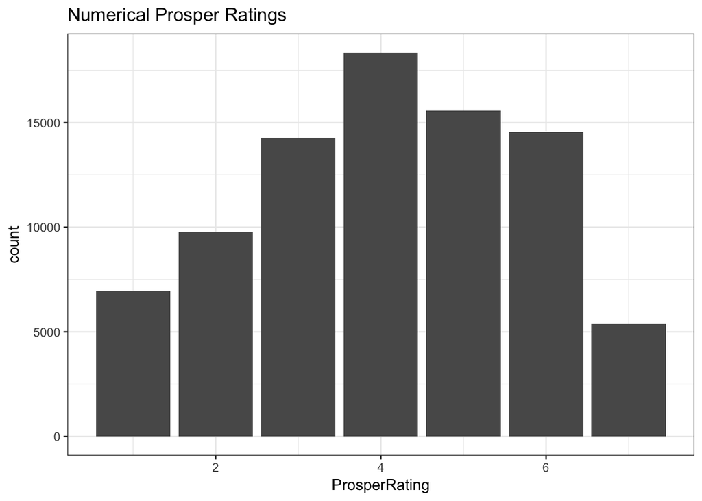

```
##    Min. 1st Qu.  Median    Mean 3rd Qu.    Max.    NA's
##   1.000   3.000   4.000   4.072   5.000   7.000   29084
```

This is a histogram of the numerical Prosper ratings. The possible values range from 1-7, with 1 being the least secure loans and 7 being the most secure. With the exception of the loans rated “7,” the ratings are distributed somewhat symmetrically.

[figure not shown]

```
##    Min. 1st Qu.  Median    Mean 3rd Qu.    Max.
##   0.000   1.000   1.000   2.774   3.000  20.000
```

This is a histogram of the categories of the loans. The “category” refers to the purpose of the loan.

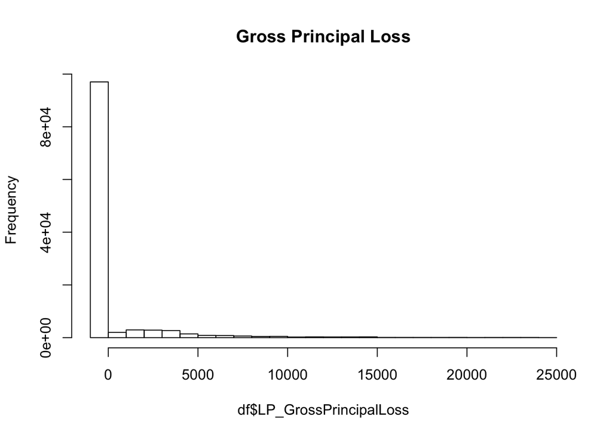

```
##    Min. 1st Qu.  Median    Mean 3rd Qu.    Max.
##   -94.2     0.0     0.0   700.4     0.0 25000.0
```

This is a histogram of the Gross Principal Loss, which is the gross principal loss is the amount charged-off on the loan (more on this in Bivariate Analysis).

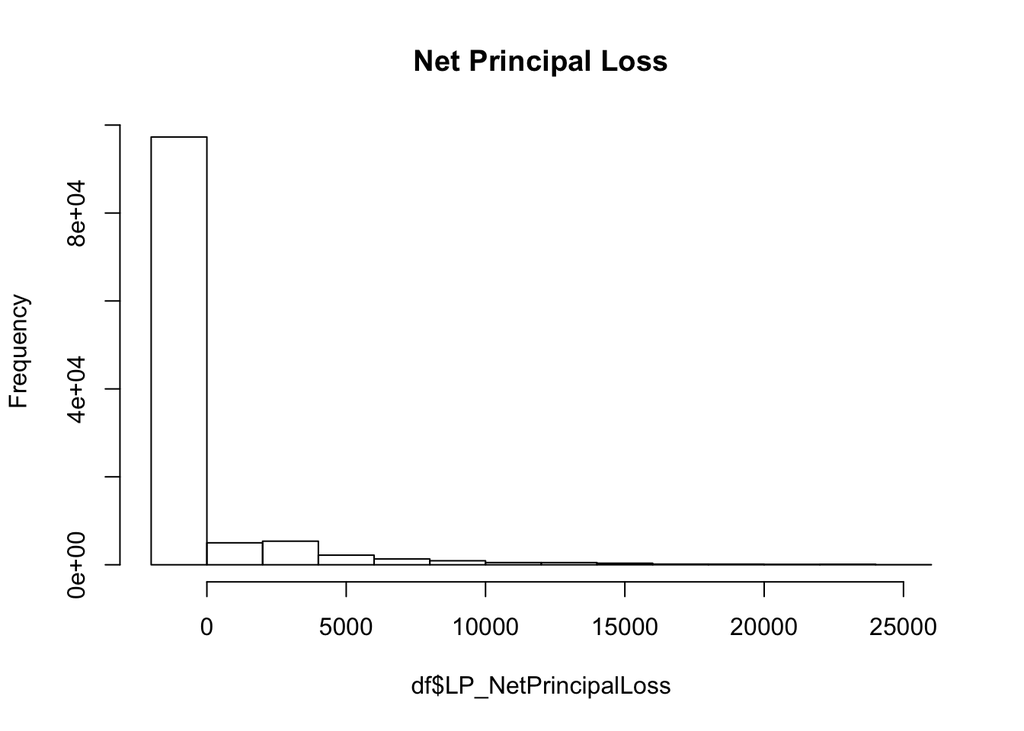

```
##    Min. 1st Qu.  Median    Mean 3rd Qu.    Max.
##  -954.6     0.0     0.0   681.4     0.0 25000.0
```

This is a histogram of the Net Principal Loss, which is the amount remaining after collecting a balance (more on this in Bivariate Analysis).

# Univariate Analysis

### What is the structure of your dataset?

There are 81 columns and 113,937 rows in the dataset.

### What other features in the dataset do you think will help support your investigation into your feature(s) of interest?

Other features that would help my investigation are the EstimatedLoss, the EstimatedReturn, the CreditGrade, and possibly the homeowning status of the borrowers. The homeowning status of the borrowers would definitely impact what kinds of loans they took out, since different lifestyles have different requirements. The grade of the loans could be important because it could determine the delinquency rate since the different types of loans have different eligibility requirements. The Estimated Loss/EstimatedReturn could also give insight into the nature of the loans.

### Did you create any new variables from existing variables in the dataset?

I did not create any new variables from the variables in the data set as it would have been unnecessary.

# Bivariate Plots Section

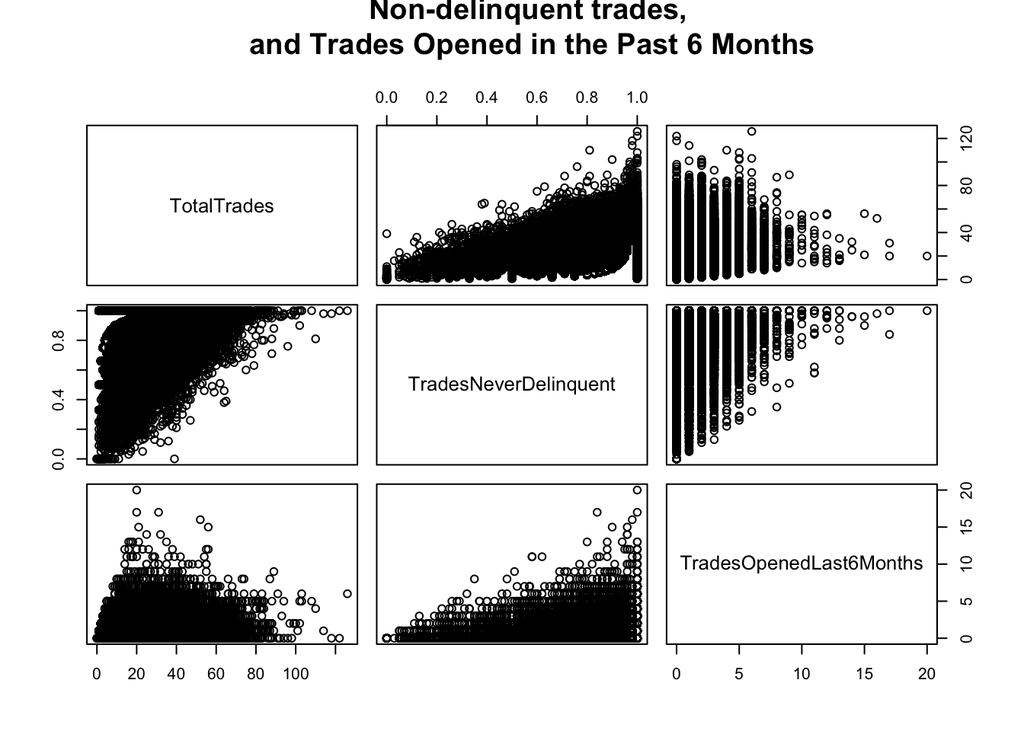

This plot matrix plots the total number of trades, the number of non-delinquent trades, and the number of trades opened over the last 6 months. I thought that the date of the trade would affect the number of non-delinquent trades, but there is not a very strong correlation.

On the other hand, there is a strong correlation between the total number of trades and the percentage of non-delinquent trades. This is not surprising because the number of trades would affect the borrowers’ ability to make good on them.

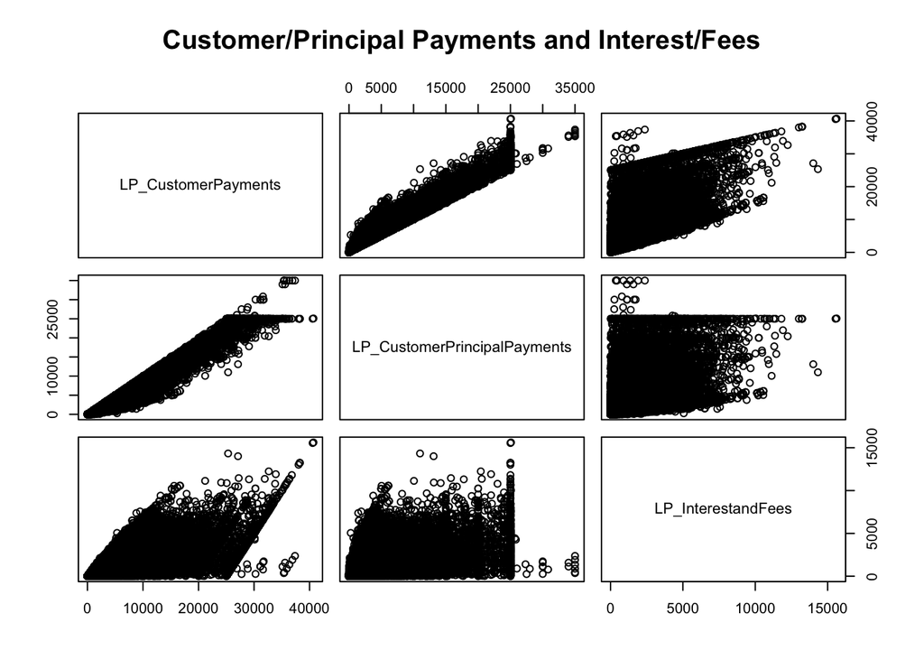

This is a plot matrix of the customer payments, the customer principal payments, and the interest and fees. As expected, there is a strong correlation between the first two values, but neither value has a meaningful relationship with the interest and fees on the loan.

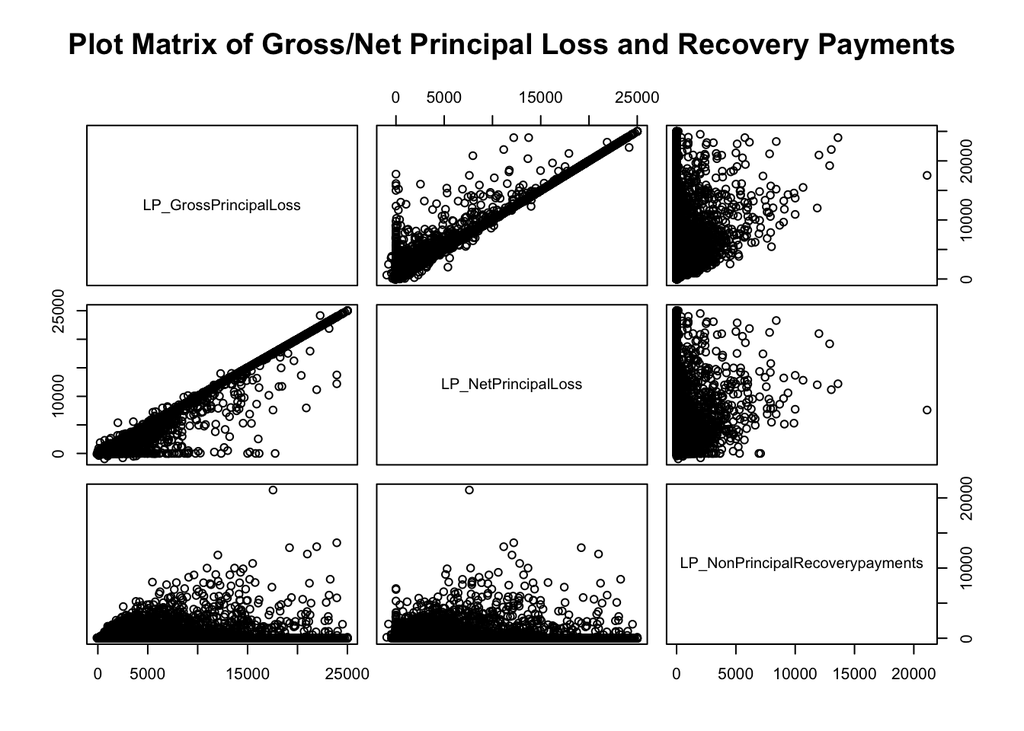

This is a plot matrix of the gross principal loss, net principal loss, and the non-principal recovery payments. The recovery payments do not have a strong correlation with the other variables, but the correlation between gross and net principal loss is nearly perfect (more on this in the Analysis section).

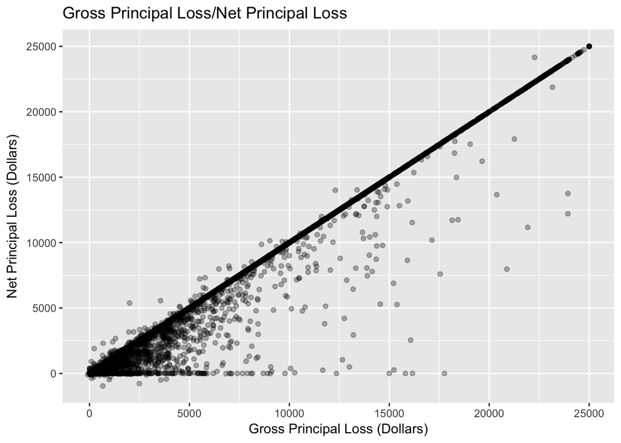

```
##    Min. 1st Qu.  Median    Mean 3rd Qu.    Max.
##   -94.2     0.0     0.0   700.4     0.0 25000.0
```

```
##    Min. 1st Qu.  Median    Mean 3rd Qu.    Max.
##  -954.6     0.0     0.0   681.4     0.0 25000.0
```

This is a plot of LP_GrossPrincipalLoss against LP_NetPrincipalLoss. The gross principal loss is the amount charged-off on the loan. The charged-off amount is the amount declared by the creditor to be unpaid, which usually happens when the borrower is delinquent. However, this does not exempt the borrower from paying off the remaining balance. The net principal loss is the amount remaining after collecting a balance.

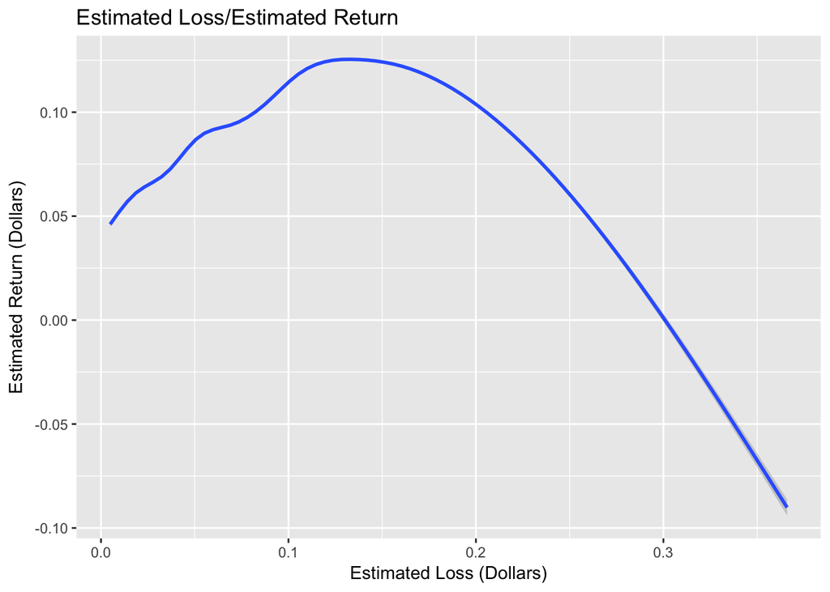

```
##    Min. 1st Qu.  Median    Mean 3rd Qu.    Max.    NA's
##   0.005   0.042   0.072   0.080   0.112   0.366   29084
```

```
##    Min. 1st Qu.  Median    Mean 3rd Qu.    Max.    NA's
##  -0.183   0.074   0.092   0.096   0.117   0.284   29084
```

This is a plot of the estimated loss and estimated return. The estimated loss is the amount estimated to be lost on charge-offs and the estimated return is the difference between the estimated effective yield rate and the estimated loss rate.

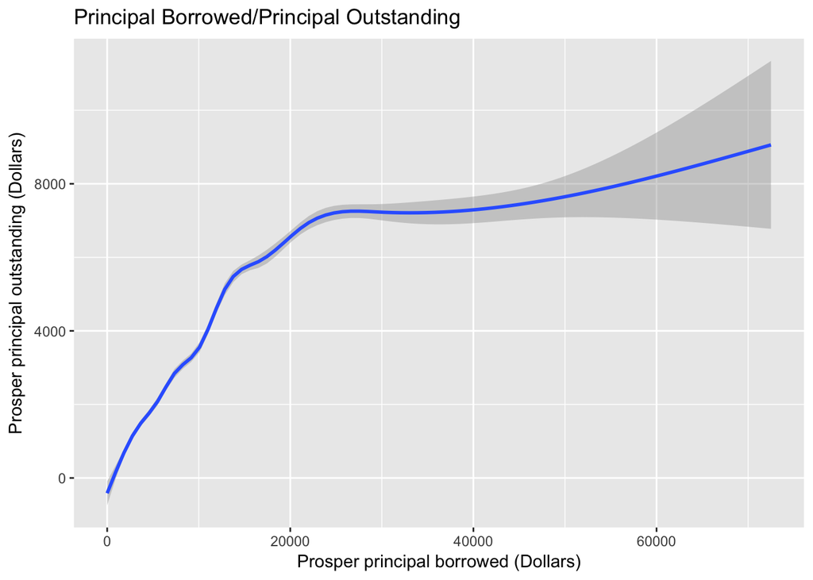

```
##    Min. 1st Qu.  Median    Mean 3rd Qu.    Max.    NA's
##       0    3500    6000    8472   11000   72500   91852
```

```
##    Min. 1st Qu.  Median    Mean 3rd Qu.    Max.    NA's
##       0       0    1627    2930    4127   23450   91852
```

This is a plot of the principal borrowed and the outstanding principal. The principal borrowed is the total principal that was borrowed at the time of the listing, and the outstanding principal is the amount that had yet to be paid when the listing was created.

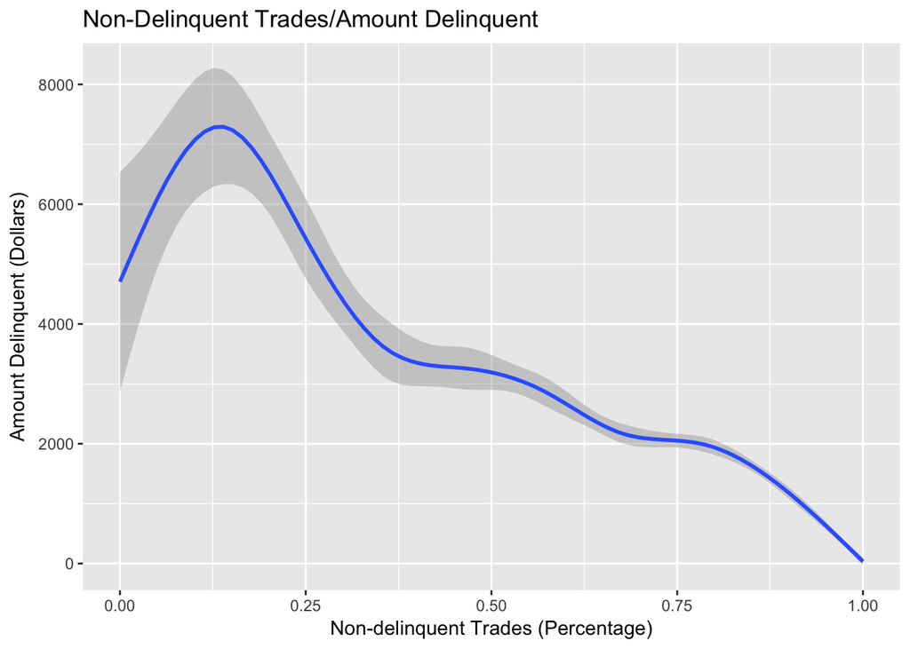

```
##    Min. 1st Qu.  Median    Mean 3rd Qu.    Max.    NA's
##   0.000   0.820   0.940   0.886   1.000   1.000    7544
```

```
##     Min.  1st Qu.   Median     Mean  3rd Qu.     Max.     NA's
##      0.0      0.0      0.0    984.5      0.0 463900.0     7622
```

This is a plot of the amount of non-delinquent trades and the delinquency amount. The amount non-delinquent trades given in this dataset is the percentage of trades that were not delinquent at the time the profile was pulled. The amount delinquent is the amount by which borrowers were overdue at the time the profile was pulled.

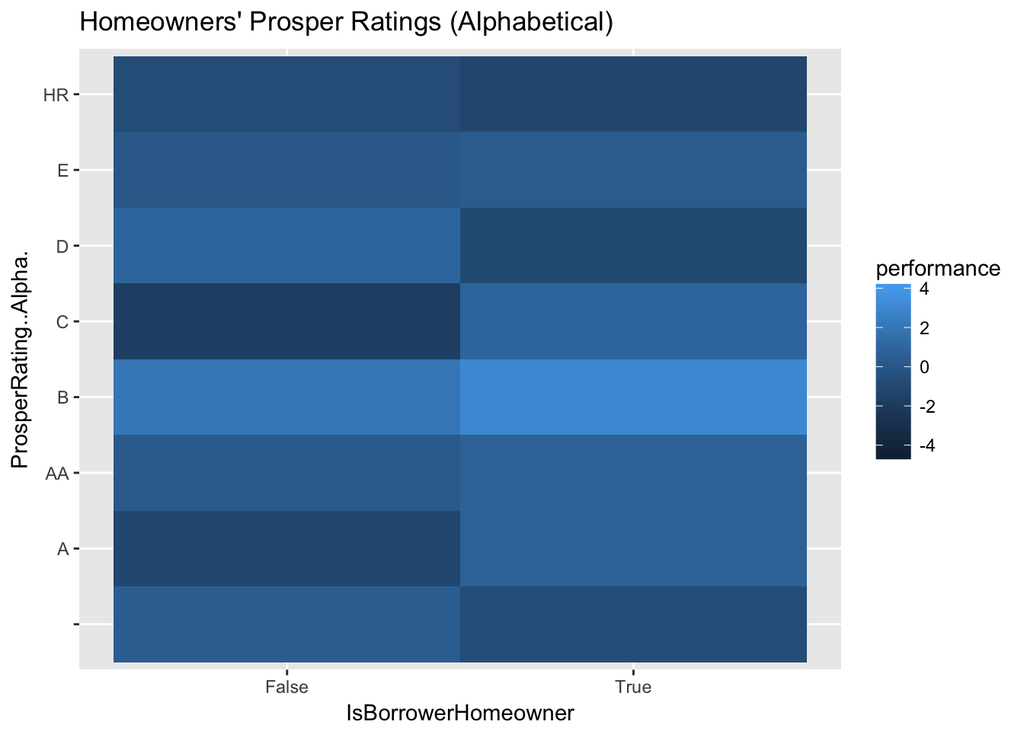

```
## False  True
## 56459 57478
```

```
##           A    AA     B     C     D     E    HR
## 29084 14551  5372 15581 18345 14274  9795  6935
```

This is a plot of the borrowers’ homeowning status and the alphabetical Prosper ratings.

# Bivariate Analysis

### Did you observe any interesting relationships between the other features (not the main feature(s) of interest)?

I expected a nearly perfect negative correlation between the number of delinquent trades and the dollar amount by which borrowers were delinquent. I thought that the people who had fewer delinquent trades would have paid off most of their debts, and therefore had less money delinquent but this was not the case: the trendline shows an odd spike, and the relationship mostly fluctuates, thereby indicating a moderately strong negative relationship, at best.

I also expected a perfect correlation between the borrowed principal amount and the outstanding principal amount because I worked under the assumption that the more money someone borrowed, the more they would owe later on, but the relationship is almost the reverse of the relationship between the number of trades delinquent and the delinquency amount-there is only a moderate correlation at best.

### What was the strongest relationship you found?

The correlation between gross principal loss and net principal loss is very strong, if not nearly perfect. This is not surprising since the net principal loss is equal to the difference between gross charge-offs and recoveries of debt, so the net principal loss is calculated from the gross principal loss. However, there some very curious outpus: according to the output from the summary function calls, the lowest value for this quantity in the dataset is -94.2. Its lowest value is -954.60. The negative amounts could be due to overpayment, which would require the creditor to refund some money.

# Multivariate Plots Section

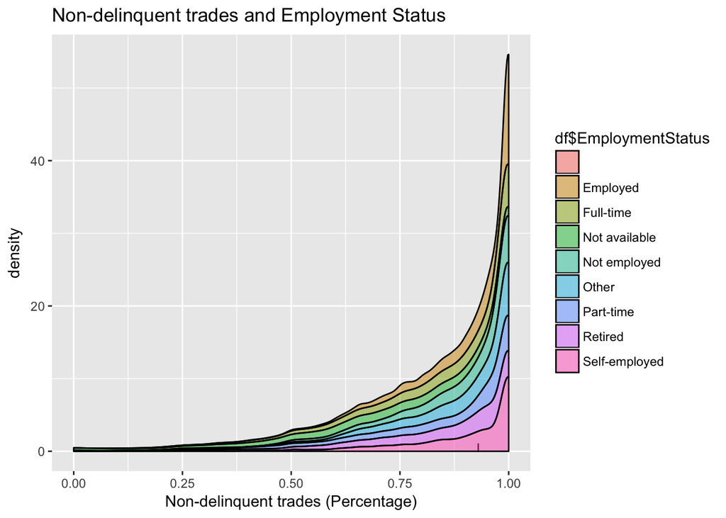

This is a density plot of the percentage of non-delinquent trades and the borrowers’ employment status.

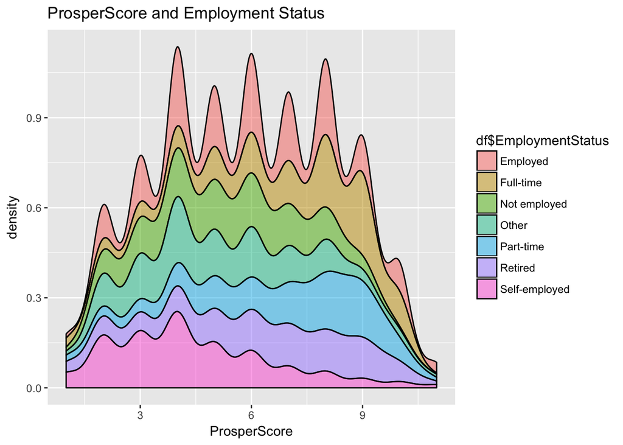

This is a density plot of the borrowers’ employment status and the numerical Prosper scores of their loans.

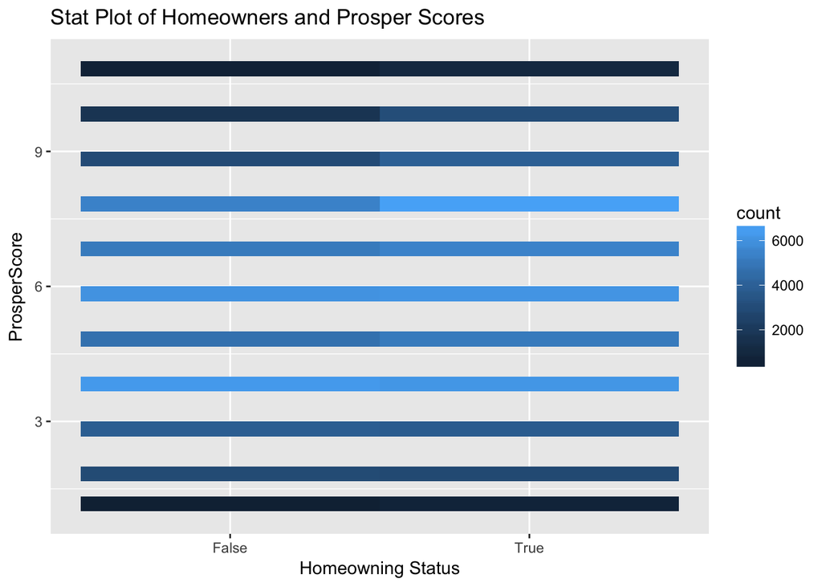

This is a stat_bin plot of the borrowers’ homeowning status and the Prosper scores of their loans. There is no meaningful relationship because there is more or less an even split among loans with high scores and low scores.

# Multivariate Analysis

### Talk about some of the relationships you observed in this part of the investigation. Were there features that strengthened each other in terms of looking at your feature(s) of interest?

I was not surprised that so many full-time workers’ took loans with higher ProsperScores. They have the income to support it, so they are more likely to be approved to take safer loans because of their improved financial standing. In this section, I also explored the relationship between the borrowers’ homeowning status and the ProsperScores of their loans. I was surprised to see that the split was almost perfectly equal. This could be because of differences in housing units (that is, some apartments are better than others, etc. These kinds of differences would account for the differences in the amounts and types of loans.)

### OPTIONAL: Did you create any models with your dataset? Discuss the strengths and limitations of your model.

# Final Plots and Summary

## Plot One

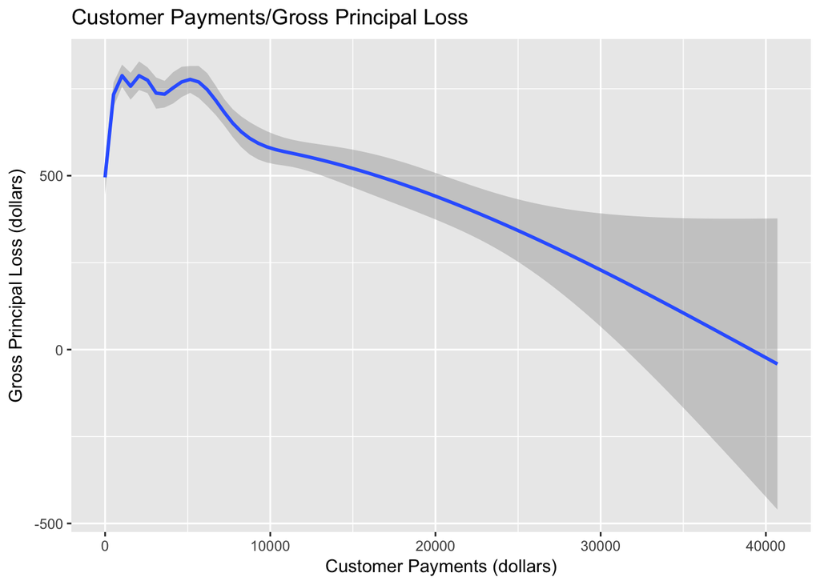

### Plot Two

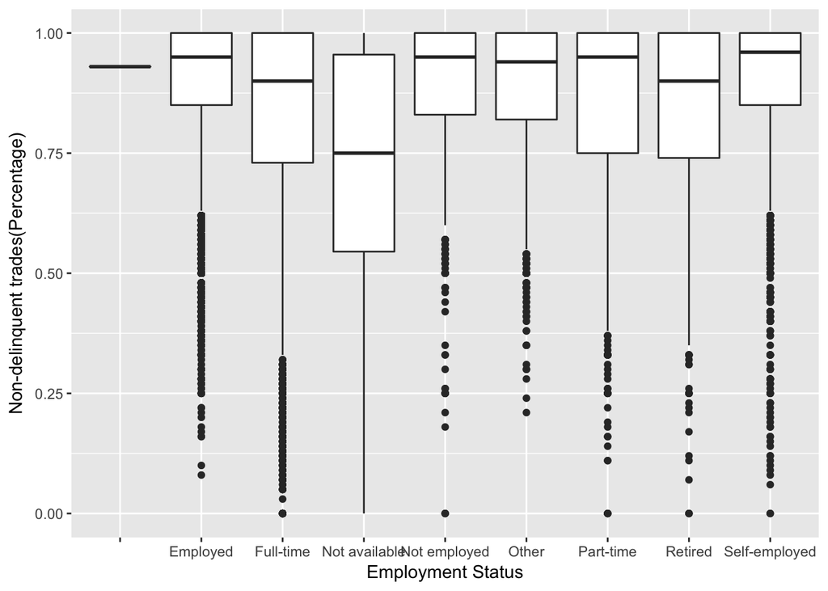

### Plot Three

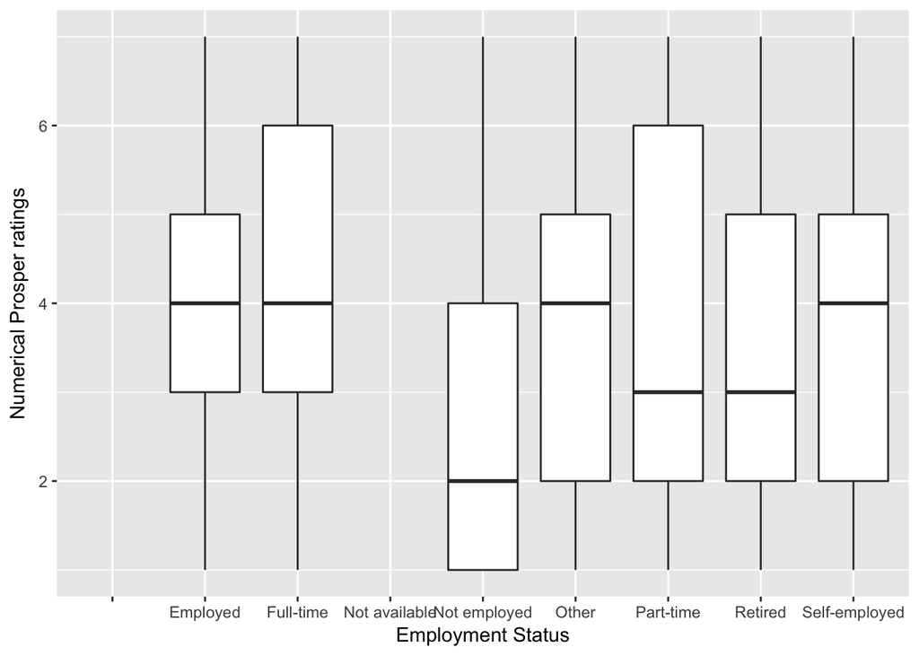

# Reflection

A big problem with the data set was the separation among employment statuses. It is never established what “Other” entails, and it is somewhat unncessary to differentiate among “Employed” and “Full-time,” “Part-time,” and “Self-Employed.” This difference shifted the results and therefore it is difficult to draw any meaningful conclusions since “Employed” is never properly defined.

For future analyses, it could be worth investigating why the data set distinguishes among “Full-time,” “Part-time,” “Employed,” and “Self-Employed” since these should all fall under the umbrella of “Employed.” Another important question for the future would be, “What is the significance of the ‘Other’ category?” It is never explained what this category is for.